# Spatial Autocorrelation Analysis: Moran’s I

- Show All Code
- Hide All Code
- View Source

Author

Eric Delmelle

Published

February 17, 2026

# 1 Introduction

Spatial autocorrelation measures the degree to which observations at nearby locations are similar to each other. In disease mapping, we use two complementary measures:

1. **Global Moran’s I**: Overall spatial autocorrelation across the entire study area
2. **Local Moran’s I (LISA)**: Identifies specific clusters and spatial outliers

# 2 Setup and Data Preparation

## 2.1 Required Packages

```r
# Set CRAN mirror
options(repos = c(CRAN = "https://cloud.r-project.org/"))

# Package installation function
install_if_needed <- function(packages) {
  for(pkg in packages) {
    if (!require(pkg, character.only = TRUE, quietly = TRUE)) {
      install.packages(pkg)
      library(pkg, character.only = TRUE)
    }
  }
}

# Load required packages
required_packages <- c(
  "sf",           # Modern spatial data handling
  "spdep",        # Spatial dependence analysis
  "tmap",         # Thematic mapping
  "RColorBrewer", # Color palettes
  "dplyr",        # Data manipulation
  "ggplot2",      # Advanced plotting
  "knitr"         # Document formatting
)

install_if_needed(required_packages)
```

## 2.2 Load and Prepare Data

We’ll use the North Carolina SIDS dataset and calculate crude mortality rates.

```r
# Load the NC SIDS dataset
nc_sids <- st_read(system.file("shape/nc.shp", package = "sf"), quiet = TRUE)

# Prepare the data with crude rates
nc_sf <- nc_sids %>%
  mutate(
    pop = as.numeric(BIR74),         # Births 1974-1978 (population at risk)
    count = as.numeric(SID74),       # SIDS deaths 1974-1978
    crude_rate = (count / pop) * 1000  # Rate per 1,000 births
  ) %>%
  filter(!is.na(pop) & !is.na(count) & pop > 0)

# Basic summary
cat("Number of counties:", nrow(nc_sf), "\n")
```

```
Number of counties: 100
```

```r
cat("Mean crude rate:", round(mean(nc_sf$crude_rate), 3), "per 1,000 births\n")
```

```
Mean crude rate: 2.046 per 1,000 births
```

```r
cat("SD of crude rate:", round(sd(nc_sf$crude_rate), 3), "\n")
```

```
SD of crude rate: 1.573
```

## 2.3 Visualize Crude Rates

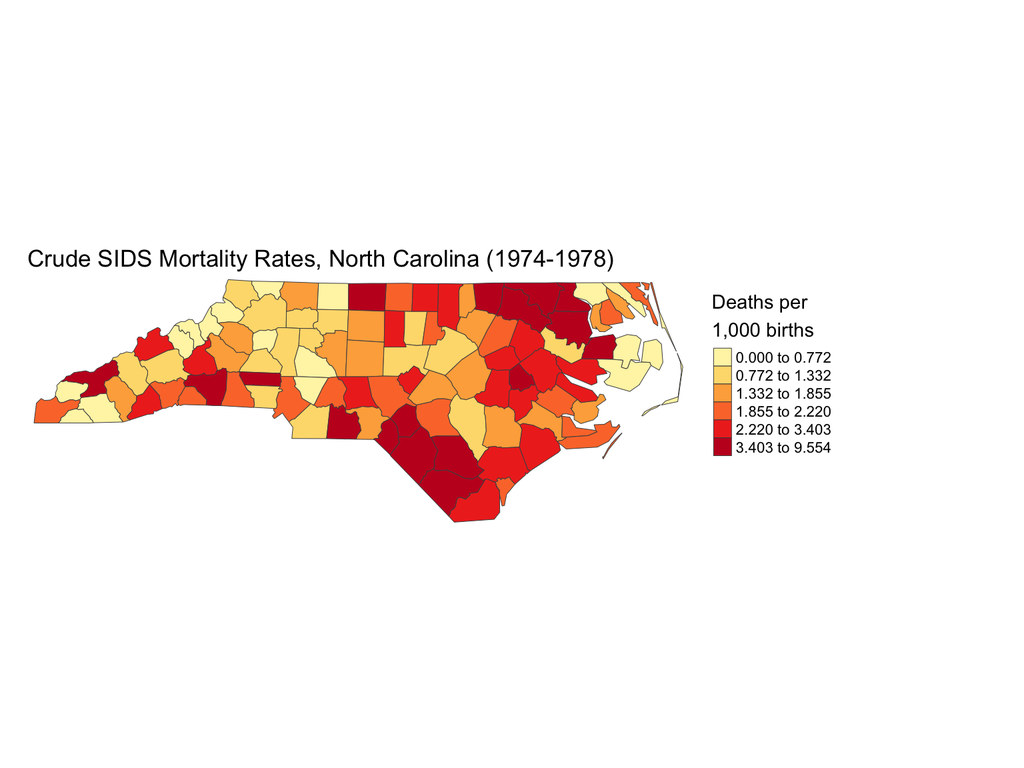

```r
tm_shape(nc_sf) +
  tm_fill("crude_rate",
          style = "quantile",
          n = 6,
          palette = "YlOrRd",
          title = "Deaths per\n1,000 births") +
  tm_borders(col = "grey30", lwd = 0.5) +
  tm_layout(
    main.title = "Crude SIDS Mortality Rates, North Carolina (1974-1978)",
    main.title.size = 1.1,
    legend.outside = TRUE,
    legend.outside.position = "right",
    frame = FALSE
  )
```

# 3 Spatial Weights Matrix

Before calculating spatial autocorrelation, we must define **who is a neighbor**. This is formalized through a **spatial weights matrix**.

## 3.1 Neighborhood Definitions

Common approaches to defining neighbors:

1. **Queen Contiguity**: Areas sharing any boundary or vertex (like the queen’s move in chess)
2. **Rook Contiguity**: Areas sharing a boundary (like the rook’s move in chess)
3. **K-Nearest Neighbors**: The K closest areas by centroid distance
4. **Distance Band**: All areas within a specified distance threshold

```r
# Convert to Spatial object for spdep compatibility
nc_sp <- as(nc_sf, "Spatial")

# Calculate county centroids
coords <- st_coordinates(st_centroid(nc_sf))

# Create different neighbor structures
nb_queen <- poly2nb(nc_sp, queen = TRUE)
nb_rook <- poly2nb(nc_sp, queen = FALSE)
nb_k4 <- knn2nb(knearneigh(coords, k = 4))
nb_k8 <- knn2nb(knearneigh(coords, k = 8))

# Summary
cat("Neighborhood Structure Comparison:\n\n")
```

```
Neighborhood Structure Comparison:
```

```r
cat("Queen Contiguity:\n")
```

```
Queen Contiguity:
```

```r
cat("  Mean neighbors:", round(mean(card(nb_queen)), 2), "\n")
```

```
  Mean neighbors: 4.9
```

```r
cat("  Min neighbors:", min(card(nb_queen)), "\n")
```

```
  Min neighbors: 2
```

```r
cat("  Max neighbors:", max(card(nb_queen)), "\n\n")
```

```
  Max neighbors: 9
```

```r
cat("Rook Contiguity:\n")
```

```
Rook Contiguity:
```

```r
cat("  Mean neighbors:", round(mean(card(nb_rook)), 2), "\n")
```

```
  Mean neighbors: 4.62
```

```r
cat("  Min neighbors:", min(card(nb_rook)), "\n")
```

```
  Min neighbors: 2
```

```r
cat("  Max neighbors:", max(card(nb_rook)), "\n\n")
```

```
  Max neighbors: 9
```

```r
cat("K=4 Nearest Neighbors:\n")
```

```
K=4 Nearest Neighbors:
```

```r
cat("  Mean neighbors:", mean(card(nb_k4)), "\n\n")
```

```
  Mean neighbors: 4
```

```r
cat("K=8 Nearest Neighbors:\n")
```

```
K=8 Nearest Neighbors:
```

```r
cat("  Mean neighbors:", mean(card(nb_k8)), "\n")
```

```
  Mean neighbors: 8
```

## 3.2 Visualize Neighborhood Connections

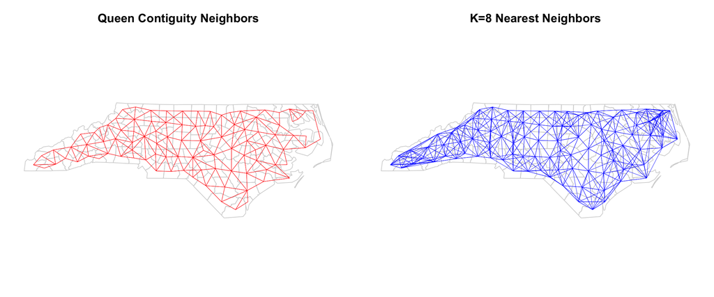

```r
par(mfrow = c(1, 2), mar = c(1, 1, 3, 1))

# Queen contiguity
plot(st_geometry(nc_sf), border = "lightgrey", main = "Queen Contiguity Neighbors")
plot(nb_queen, coords, add = TRUE, col = "red", lwd = 0.5, points = FALSE)

# K=8 nearest neighbors
plot(st_geometry(nc_sf), border = "lightgrey", main = "K=8 Nearest Neighbors")
plot(nb_k8, coords, add = TRUE, col = "blue", lwd = 0.5, points = FALSE)
```

```r
par(mfrow = c(1, 1))
```

## 3.3 Row-Standardized Weights

For Moran’s I calculation, we convert the neighbor list to a **row-standardized spatial weights matrix** where each neighbor receives equal weight and weights sum to 1 for each area.

```r
# Create row-standardized weights matrix
listw_queen <- nb2listw(nb_queen, style = "W", zero.policy = TRUE)

cat("Spatial weights matrix created:\n")
```

```
Spatial weights matrix created:
```

```r
cat("Style: W (row-standardized)\n")
```

```
Style: W (row-standardized)
```

```r
cat("Number of regions:", length(listw_queen$neighbours), "\n")
```

```
Number of regions: 100
```

```r
cat("Total number of links:", sum(card(nb_queen)), "\n")
```

```
Total number of links: 490
```

# 4 Global Moran’s I

## 4.1 Theoretical Foundation

**Global Moran’s I** measures the overall spatial autocorrelation in a dataset. It is analogous to a Pearson correlation coefficient but for spatial data.

### 4.1.1 The Formula

$$I = \frac{n}{\sum_i \sum_j w_{ij}} \cdot \frac{\sum_i \sum_j w_{ij}(x_i - \bar{x})(x_j - \bar{x})}{\sum_i (x_i - \bar{x})^2}$$

Where:

- $n$ = number of spatial units
- $x_i$ = value at location $i$ (e.g., crude rate)
- $\bar{x}$ = mean value across all locations
- $w_{ij}$ = spatial weight between locations $i$ and $j$

**Simplified interpretation**: Moran’s I measures whether similar values (both high or both low) tend to be located near each other.

### 4.1.2 Interpretation of Moran’s I

- **I > 0**: Positive spatial autocorrelation (similar values cluster)
- **I ≈ 0**: No spatial autocorrelation (random spatial pattern)
- **I < 0**: Negative spatial autocorrelation (dissimilar values cluster - rare in practice)

**Range**: Typically between -1 and +1, though exact bounds depend on the spatial weights structure.

### 4.1.3 Expected Value Under Null Hypothesis

If there is **no spatial autocorrelation** (complete spatial randomness), the expected value is:

$$E[I] = \frac{-1}{n-1}$$

For our data with 100 counties: $E[I] = -0.0101$

### 4.1.4 Statistical Significance

We test the null hypothesis: **“There is no spatial autocorrelation”**

Two approaches:

1. **Permutation test**: Randomly permute the values across locations many times and compare observed I to the distribution of permuted I values
2. **Analytical approach**: Assume normality and use theoretical variance

## 4.2 Implementation

```r
# Calculate Global Moran's I
moran_test <- moran.test(nc_sf$crude_rate, listw_queen)

# Display results
cat("Global Moran's I Test Results\n")
```

```
Global Moran's I Test Results
```

```r
cat("==============================\n\n")
cat("Moran's I statistic:", round(moran_test$estimate[1], 4), "\n")
```

```
Moran's I statistic: 0.2309
```

```r
cat("Expected value (random):", round(moran_test$estimate[2], 4), "\n")
```

```
Expected value (random): -0.0101
```

```r
cat("Variance:", round(moran_test$estimate[3], 6), "\n\n")
```

```
Variance: 0.004065
```

```r
cat("Z-score:", round(moran_test$statistic, 4), "\n")
```

```
Z-score: 3.7801
```

```r
cat("P-value:", format.pval(moran_test$p.value, digits = 4), "\n\n")
```

```
P-value: 7.839e-05
```

```r
if (moran_test$p.value < 0.001) {
  cat("Interpretation: Highly significant positive spatial autocorrelation\n")
} else if (moran_test$p.value < 0.05) {
  cat("Interpretation: Significant positive spatial autocorrelation\n")
} else {
  cat("Interpretation: No significant spatial autocorrelation\n")
}
```

```
Interpretation: Highly significant positive spatial autocorrelation
```

```r
## Moran Scatterplot
```

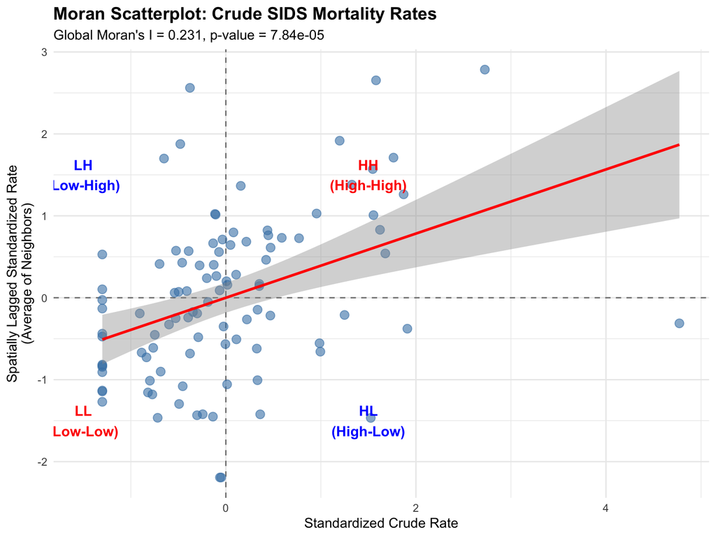

```r
# Calculate spatially lagged values
nc_sf$lag_rate <- lag.listw(listw_queen, nc_sf$crude_rate)

# Standardize variables for plotting
nc_sf$std_rate <- scale(nc_sf$crude_rate)
nc_sf$std_lag <- scale(nc_sf$lag_rate)

# Create Moran scatterplot
ggplot(nc_sf, aes(x = std_rate, y = std_lag)) +
  geom_hline(yintercept = 0, linetype = "dashed", color = "grey50") +
  geom_vline(xintercept = 0, linetype = "dashed", color = "grey50") +
  geom_point(alpha = 0.6, size = 3, color = "steelblue") +
  geom_smooth(method = "lm", se = TRUE, color = "red") +
  annotate("text", x = 1.5, y = 1.5, label = "HH\n(High-High)",
           color = "red", fontface = "bold", size = 4) +
  annotate("text", x = -1.5, y = 1.5, label = "LH\n(Low-High)",
           color = "blue", fontface = "bold", size = 4) +
  annotate("text", x = 1.5, y = -1.5, label = "HL\n(High-Low)",
           color = "blue", fontface = "bold", size = 4) +
  annotate("text", x = -1.5, y = -1.5, label = "LL\n(Low-Low)",
           color = "red", fontface = "bold", size = 4) +
  labs(
    title = "Moran Scatterplot: Crude SIDS Mortality Rates",
    subtitle = paste0("Global Moran's I = ",
                     round(moran_test$estimate[1], 3),
                     ", p-value = ",
                     format.pval(moran_test$p.value, digits = 3)),
    x = "Standardized Crude Rate",
    y = "Spatially Lagged Standardized Rate\n(Average of Neighbors)"
  ) +
  theme_minimal() +
  theme(plot.title = element_text(size = 14, face = "bold"))
```

**Quadrant interpretation**:

- **HH (High-High)**: High rates with high-rate neighbors
- **LL (Low-Low)**: Low rates with low-rate neighbors
- **HL (High-Low)**: High rates with low-rate neighbors
- **LH (Low-High)**: Low rates with high-rate neighbors

# 5 Local Moran’s I (LISA)

## 5.1 Theoretical Foundation

**Local Indicators of Spatial Association (LISA)** decompose global spatial autocorrelation into local contributions, identifying specific locations that contribute most to the overall pattern.

### 5.1.1 The Formula

For each location $i$:

$$I_i = \frac{x_i - \bar{x}}{m_2} \sum_j w_{ij}(x_j - \bar{x})$$

Where:

- $I_i$ = Local Moran’s I at location $i$
- $x_i$ = value at location $i$
- $\bar{x}$ = global mean
- $m_2 = \frac{\sum_i (x_i - \bar{x})^2}{n}$ (variance)
- $w_{ij}$ = spatial weight between $i$ and $j$

**Key property**: $\sum_i I_i \propto I$ (sum of local statistics proportional to global statistic)

### 5.1.2 Interpretation

Each $I_i$ measures the extent of significant spatial clustering of similar (positive) or dissimilar (negative) values around location $i$.

### 5.1.3 Statistical Significance

For each location, we test: **“Is the local spatial pattern significantly different from random?”**

1. Hold location $i$ fixed
2. Randomly permute values at all other locations
3. Recalculate $I_i$ for each permutation
4. Compare observed $I_i$ to permutation distribution

### 5.1.4 Cluster Types

Based on the sign of $I_i$ and the quadrant in the Moran scatterplot:

- **HH (High-High)**: Hot spots - high values surrounded by high values
- **LL (Low-Low)**: Cold spots - low values surrounded by low values
- **HL (High-Low)**: Spatial outliers - high values surrounded by low values
- **LH (Low-High)**: Spatial outliers - low values surrounded by high values

## 5.2 Implementation

```r
# Calculate Local Moran's I
set.seed(12345)
local_moran <- localmoran(nc_sf$crude_rate, listw_queen)

# Add results to spatial data
nc_sf <- nc_sf %>%
  mutate(
    local_I = local_moran[, "Ii"],
    local_I_pvalue = local_moran[, "Pr(z != E(Ii))"],
    local_I_zscore = local_moran[, "Z.Ii"]
  )

# Summary of local statistics
cat("Local Moran's I Summary\n")
```

```
Local Moran's I Summary
```

```r
cat("=======================\n\n")
cat("Number of counties:", nrow(nc_sf), "\n")
```

```
Number of counties: 100
```

```r
cat("Mean Local I:", round(mean(nc_sf$local_I), 4), "\n")
```

```
Mean Local I: 0.2309
```

```r
cat("SD Local I:", round(sd(nc_sf$local_I), 4), "\n\n")
```

```
SD Local I: 0.6757
```

```r
# Significant clusters (p < 0.05)
sig_count <- sum(nc_sf$local_I_pvalue < 0.05)
cat("Significant clusters/outliers (p < 0.05):", sig_count,
    paste0("(", round(sig_count/nrow(nc_sf)*100, 1), "%)"), "\n")
```

```
Significant clusters/outliers (p < 0.05): 10 (10%)
```

```r
# Highly significant (p < 0.01)
highly_sig <- sum(nc_sf$local_I_pvalue < 0.01)
cat("Highly significant (p < 0.01):", highly_sig,
    paste0("(", round(highly_sig/nrow(nc_sf)*100, 1), "%)"), "\n")
```

```
Highly significant (p < 0.01): 5 (5%)
```

## 5.3 Classify Cluster Types

```r
# Classify each location into cluster type
nc_sf <- nc_sf %>%
  mutate(
    # Standardize for quadrant classification
    std_rate_local = scale(crude_rate)[,1],
    std_lag_local = scale(lag_rate)[,1],

    # Determine quadrant
    quadrant = case_when(
      std_rate_local > 0 & std_lag_local > 0 ~ "HH",
      std_rate_local < 0 & std_lag_local < 0 ~ "LL",
      std_rate_local > 0 & std_lag_local < 0 ~ "HL",
      std_rate_local < 0 & std_lag_local > 0 ~ "LH",
      TRUE ~ "Not Significant"
    ),

    # Create cluster type variable (only for significant at p < 0.05)
    cluster_type = ifelse(local_I_pvalue < 0.05, quadrant, "Not Significant"),

    # More stringent: p < 0.01
    cluster_type_strict = ifelse(local_I_pvalue < 0.01, quadrant, "Not Significant")
  )

# Tabulate cluster types
cat("\nCluster Type Classification (p < 0.05):\n")
```

```
Cluster Type Classification (p < 0.05):
```

```r
table(nc_sf$cluster_type)
```

```
             HH              LH              LL Not Significant
              4               3               3              90
```

```r
cat("\nCluster Type Classification (p < 0.01):\n")
```

```
Cluster Type Classification (p < 0.01):
```

```r
table(nc_sf$cluster_type_strict)
```

```
             HH              LH Not Significant
              3               2              95
```

## 5.4 Map Local Moran’s I Values

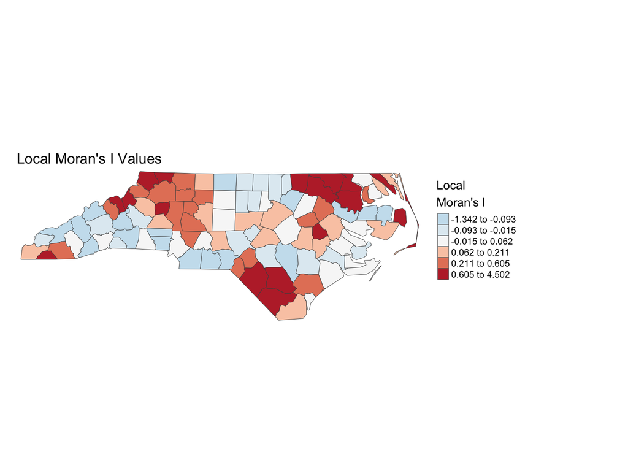

```r
# Map of Local Moran's I values
tm_shape(nc_sf) +
  tm_fill("local_I",
          style = "quantile",
          n = 6,
          palette = "-RdBu",  # Diverging palette
          title = "Local\nMoran's I") +
  tm_borders(col = "grey30", lwd = 0.5) +
  tm_layout(
    main.title = "Local Moran's I Values",
    main.title.size = 1.1,
    legend.outside = TRUE,
    legend.outside.position = "right",
    frame = FALSE
  )
```

## 5.5 Map Statistical Significance

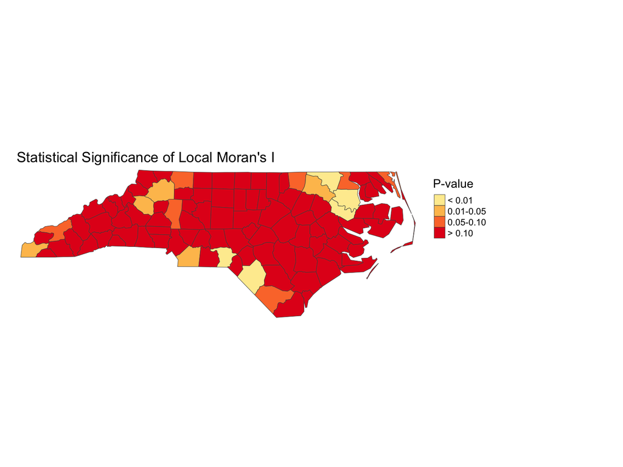

```r
# Map of p-values
tm_shape(nc_sf) +
  tm_fill("local_I_pvalue",
          style = "fixed",
          breaks = c(0, 0.01, 0.05, 0.1, 1),
          palette = "YlOrRd",
          labels = c("< 0.01", "0.01-0.05", "0.05-0.10", "> 0.10"),
          title = "P-value") +
  tm_borders(col = "grey30", lwd = 0.5) +
  tm_layout(
    main.title = "Statistical Significance of Local Moran's I",
    main.title.size = 1.1,
    legend.outside = TRUE,
    legend.outside.position = "right",
    frame = FALSE
  )
```

## 5.6 LISA Cluster Map

The most informative visualization shows **both** cluster type **and** statistical significance:

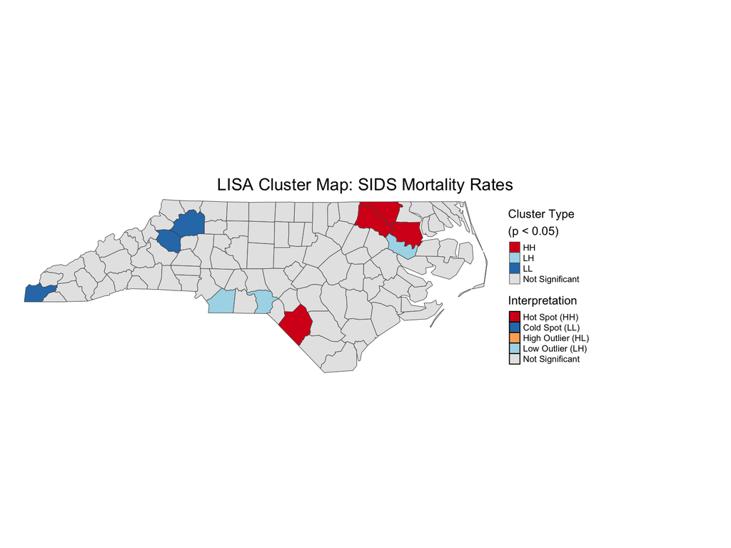

```r
# Define colors for cluster types
lisa_colors <- c(
  "HH" = "#d7191c",           # Red for hot spots
  "LL" = "#2c7bb6",           # Blue for cold spots
  "HL" = "#fdae61",           # Orange for high outliers
  "LH" = "#abd9e9",           # Light blue for low outliers
  "Not Significant" = "grey90"
)

# Create LISA map (p < 0.05)
tm_shape(nc_sf) +
  tm_fill("cluster_type",
          palette = lisa_colors,
          title = "Cluster Type\n(p < 0.05)") +
  tm_borders(col = "grey30", lwd = 0.5) +
  tm_layout(
    main.title = "LISA Cluster Map: SIDS Mortality Rates",
    main.title.size = 1.1,
    main.title.position = c("center", "top"),
    legend.outside = TRUE,
    legend.outside.position = "right",
    frame = FALSE
  ) +
  tm_add_legend(
    type = "fill",
    labels = c("Hot Spot (HH)", "Cold Spot (LL)",
               "High Outlier (HL)", "Low Outlier (LH)",
               "Not Significant"),
    col = lisa_colors,
    title = "Interpretation"
  )
```

## 5.7 More Conservative LISA Map (p < 0.01)

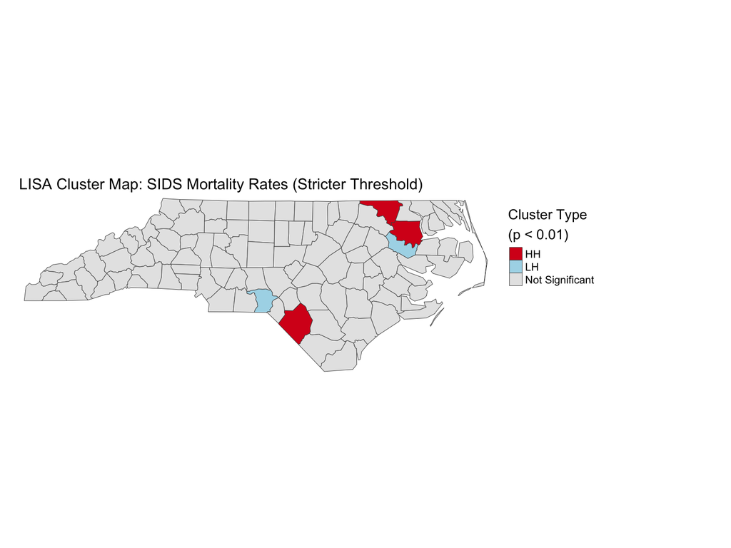

```r
# Create LISA map with stricter significance threshold
tm_shape(nc_sf) +
  tm_fill("cluster_type_strict",
          palette = lisa_colors,
          title = "Cluster Type\n(p < 0.01)") +
  tm_borders(col = "grey30", lwd = 0.5) +
  tm_layout(
    main.title = "LISA Cluster Map: SIDS Mortality Rates (Stricter Threshold)",
    main.title.size = 1.0,
    legend.outside = TRUE,
    legend.outside.position = "right",
    frame = FALSE
  )
```

## 5.8 Side-by-Side Comparison

Compare the crude rates with the LISA clusters to see how local spatial autocorrelation relates to the underlying rate pattern:

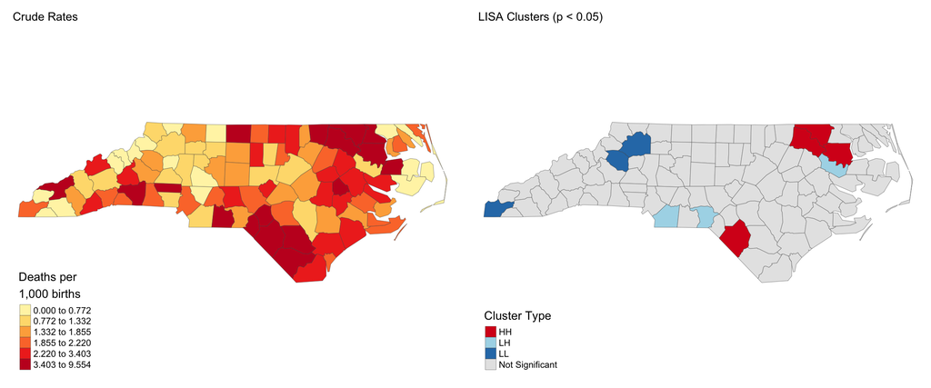

```r
# Crude rate map
map1 <- tm_shape(nc_sf) +
  tm_fill("crude_rate",
          style = "quantile",
          n = 6,
          palette = "YlOrRd",
          title = "Deaths per\n1,000 births") +
  tm_borders(col = "grey30", lwd = 0.3) +
  tm_layout(
    main.title = "Crude Rates",
    main.title.size = 0.9,
    legend.outside = FALSE,
    legend.position = c("left", "bottom"),
    frame = FALSE
  )

# LISA cluster map
map2 <- tm_shape(nc_sf) +
  tm_fill("cluster_type",
          palette = lisa_colors,
          title = "Cluster Type") +
  tm_borders(col = "grey30", lwd = 0.3) +
  tm_layout(
    main.title = "LISA Clusters (p < 0.05)",
    main.title.size = 0.9,
    legend.outside = FALSE,
    legend.position = c("left", "bottom"),
    frame = FALSE
  )

tmap_arrange(map1, map2, ncol = 2)
```

## 5.9 Identify Specific Clusters

Let’s identify and describe the significant clusters:

```r
# High-High clusters (hot spots)
hh_clusters <- nc_sf %>%
  filter(cluster_type == "HH") %>%
  st_drop_geometry() %>%
  arrange(desc(crude_rate)) %>%
  select(NAME, crude_rate, local_I, local_I_pvalue)

cat("HIGH-HIGH CLUSTERS (Hot Spots):\n")
```

```
HIGH-HIGH CLUSTERS (Hot Spots):
```

```r
cat("===============================\n")
if (nrow(hh_clusters) > 0) {
  print(kable(hh_clusters, digits = 3,
              col.names = c("County", "Crude Rate", "Local I", "P-value")))
} else {
  cat("No significant HH clusters detected.\n")
}
```

```
|County      | Crude Rate| Local I| P-value|
|:-----------|----------:|-------:|-------:|
|Northampton |      6.334|   4.502|   0.000|
|Halifax     |      4.989|   1.394|   0.035|
|Bertie      |      4.532|   2.487|   0.000|
|Robeson     |      3.930|   1.359|   0.009|
```

```r
cat("\n")
```

```r
# Low-Low clusters (cold spots)
ll_clusters <- nc_sf %>%
  filter(cluster_type == "LL") %>%
  st_drop_geometry() %>%
  arrange(crude_rate) %>%
  select(NAME, crude_rate, local_I, local_I_pvalue)

cat("LOW-LOW CLUSTERS (Cold Spots):\n")
```

```
LOW-LOW CLUSTERS (Cold Spots):
```

```r
cat("==============================\n")
if (nrow(ll_clusters) > 0) {
  print(kable(ll_clusters, digits = 3,
              col.names = c("County", "Crude Rate", "Local I", "P-value")))
} else {
  cat("No significant LL clusters detected.\n")
}
```

```
|County   | Crude Rate| Local I| P-value|
|:--------|----------:|-------:|-------:|
|Wilkes   |      1.271|   0.383|   0.023|
|Caldwell |      1.663|   0.208|   0.033|
|Cherokee |      1.947|   0.082|   0.023|
```

```r
cat("\n")
```

```r
# High-Low outliers
hl_outliers <- nc_sf %>%
  filter(cluster_type == "HL") %>%
  st_drop_geometry() %>%
  arrange(desc(crude_rate)) %>%
  select(NAME, crude_rate, local_I, local_I_pvalue)

cat("HIGH-LOW OUTLIERS:\n")
```

```
HIGH-LOW OUTLIERS:
```

```r
cat("==================\n")
if (nrow(hl_outliers) > 0) {
  print(kable(hl_outliers, digits = 3,
              col.names = c("County", "Crude Rate", "Local I", "P-value")))
} else {
  cat("No significant HL outliers detected.\n")
}
```

```
No significant HL outliers detected.
```

```r
cat("\n")
```

```r
# Low-High outliers
lh_outliers <- nc_sf %>%
  filter(cluster_type == "LH") %>%
  st_drop_geometry() %>%
  arrange(crude_rate) %>%
  select(NAME, crude_rate, local_I, local_I_pvalue)

cat("LOW-HIGH OUTLIERS:\n")
```

```
LOW-HIGH OUTLIERS:
```

```r
cat("==================\n")
if (nrow(lh_outliers) > 0) {
  print(kable(lh_outliers, digits = 3,
              col.names = c("County", "Crude Rate", "Local I", "P-value")))
} else {
  cat("No significant LH outliers detected.\n")
}
```

```
|County   | Crude Rate| Local I| P-value|
|:--------|----------:|-------:|-------:|
|Union    |      1.022|  -0.654|   0.044|
|Martin   |      1.291|  -0.533|   0.006|
|Richmond |      1.451|  -0.574|   0.001|
```

## 5.10 Distribution of Local I by Cluster Type

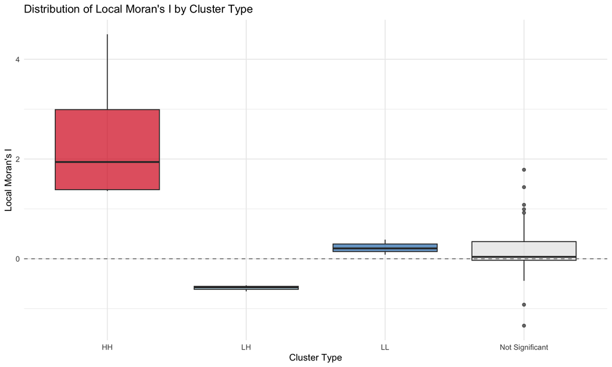

```r
# Box plot of Local I by cluster type
ggplot(nc_sf, aes(x = cluster_type, y = local_I, fill = cluster_type)) +
  geom_boxplot(alpha = 0.7) +
  geom_hline(yintercept = 0, linetype = "dashed", color = "grey50") +
  scale_fill_manual(values = lisa_colors) +
  labs(
    title = "Distribution of Local Moran's I by Cluster Type",
    x = "Cluster Type",
    y = "Local Moran's I"
  ) +
  theme_minimal() +
  theme(legend.position = "none")
```

# 6 References

Key references for Moran’s I and LISA:

- Anselin, L. (1995). Local indicators of spatial association—LISA. *Geographical Analysis*, 27(2), 93-115.
- Moran, P. A. (1950). Notes on continuous stochastic phenomena. *Biometrika*, 37(1/2), 17-23.
- Cliff, A. D., & Ord, J. K. (1981). *Spatial processes: models & applications*. Pion.
- Getis, A., & Ord, J. K. (1992). The analysis of spatial association by use of distance statistics. *Geographical Analysis*, 24(3), 189-206.

R package documentation:

- Bivand, R. S., & Wong, D. W. (2018). Comparing implementations of global and local indicators of spatial association. *TEST*, 27(3), 716-748.
- `spdep` package: https://r-spatial.github.io/spdep/

*Document created with R version 4.3.1 and `spdep` version 1.3.1*